# Basic Differential Analysis

MRC LMS Bioinformatics Core

27 September 2018

In this exercise, we will read in a count data from erythroblast differentiation experiment in mice. This data was downloaded from GEO database (http://www.ncbi.nlm.nih.gov/geo/query/acc.cgi?acc=GSE49843) and aligned to mm9 genome assembly using Rsubread R package. More details with regards to this experiment please refer to (http://www.ncbi.nlm.nih.gov/pubmed/24092935).

(Note: Gene identifiers are entrez gene ids)

**Material**

Please go to the folder “/course/exercise/”

- Sample description: Exercise_ShortRNAseq_sample.info
- Count data: Exercise_ShortRNAseq_counts.csv
1. Read in the sample information and count data. Identify how many factors this experiment involves.

```r
# please change it to your exercise directory
setwd("/Volumes/bioinfomatics$/yfwang/CBW/RNAseq_CBW2018/course/exercise")

suppressPackageStartupMessages(library(DESeq2))

# load the sample description that we generated manually for this exercise

targetsE <- read.table("Exercise_ShortRNAseq_sample.info",sep="\t",header=TRUE)

# check the content of "targets" object that we just created

targetsE
```

```
##              filename sample condition batch
## 1    control_FFa1.bam   FFa1       FFa     a
## 2    control_FFa2.bam   FFa2       FFa     b
## 3    control_FFa3.bam   FFa3       FFa     c
## 4 TMC_mutant_KOa1.bam   KOa1       KOa     a
## 5 TMC_mutant_KOa2.bam   KOa2       KOa     b
## 6 TMC_mutant_KOa3.bam   KOa3       KOa     c
## 7 TMC_mutant_KOb1.bam   KOb1       KOb     a
## 8 TMC_mutant_KOb2.bam   KOb2       KOb     b
## 9 TMC_mutant_KOb3.bam   KOb3       KOb     c
```

```r
# load the count information.

AllCountsE<-read.csv(file="Exercise_ShortRNAseq_counts.csv",header=T,row.names=1)

# see the what is in the counts.csv

head(AllCountsE)
```

```
##           control_FFa1.bam control_FFa2.bam control_FFa3.bam
## 497097                  16               16                0
## 100503874               20                0                0
## 100038431                0                0                2
## 19888                   11                0               10
## 20671                   14               16                0
## 27395                  465              193              596
##           mutant_KOa1.bam mutant_KOa2.bam mutant_KOa3.bam mutant_KOb1.bam
## 497097                 21              16              27              20
## 100503874              64               0               4               5
## 100038431               0               0               8               0
## 19888                 113               0              26              14
## 20671                  40               8              33              33
## 27395                 436             686             572            1378
##           mutant_KOb2.bam mutant_KOb3.bam
## 497097                  0               2
## 100503874               0               2
## 100038431               0               0
## 19888                   6              16
## 20671                  12              24
## 27395                1901            1553
```

In this experiment, we have two factors, namely, condition and batch. (ps: we introduced the ‘mock’ batch factor for this exercise. In the original publication, the batch effect was not discussed).

For the condition factor, we have 3 levels, namely FFa, KOa and KOb.

For the batch factor, we have 3 levels, namely a, b and c.

2. Construct DESeqDataSet object using sample information and counts data.

```r
# We provide entrez_id as identifier for this exercise

cDataE<-data.frame(name=targetsE$sample,condition=targetsE$condition,batch=targetsE$batch)

ddsE<-DESeqDataSetFromMatrix(countData= AllCountsE,colData=cDataE,design=~condition)
```

3. 1. Find the number of genes that are changed in knockdown samples versus control, i.e. KOa vs FFa and KOb vs FFa, at FDR 0.05 irrespective of fold change.
2. Find the number of genes that are changed in the above situation with fold change threshold, i.e. fold change ratio > 2.

```r
ddsE<-DESeq(ddsE)
## estimating size factors
## estimating dispersions
## gene-wise dispersion estimates
## mean-dispersion relationship
## final dispersion estimates
## fitting model and testing

# shows how many genes were differentially expressed in KOa vs FFa, with FDR<0.05
res1<-results(ddsE, contrast=c("condition","KOa","FFa"))
summary(res1,alpha=0.05)
```

```
##
## out of 24695 with nonzero total read count
## adjusted p-value < 0.05
## LFC > 0 (up)       : 774, 3.1%
## LFC < 0 (down)     : 913, 3.7%
## outliers [1]       : 54, 0.22%
## low counts [2]     : 4772, 19%
## (mean count < 5)
## [1] see 'cooksCutoff' argument of ?results
## [2] see 'independentFiltering' argument of ?results
```

```r
# shows how many genes were differentially expressed in KOa vs FFa, with FDR<0.05 and fold change ratio > 2
DE_res1<- res1[complete.cases(res1$padj),]
DE_res1<- DE_res1[DE_res1$padj<0.05 & abs(DE_res1$log2FoldChange)>1,]

# shows how many genes were differentially expressed in KOb vs FFa, with FDR<0.05
res2<-results(ddsE, contrast=c("condition","KOb","FFa"))

# shows how many genes were differentially expressed in KOa vs FFa, with FDR<0.05 and fold change ratio > 2
DE_res2<- res2[complete.cases(res2$padj),]
DE_res2<- DE_res2[DE_res2$padj<0.05 & abs(DE_res2$log2FoldChange)>1,]
```

[output not shown]

4. Using Biomart, add extra columns to the results dataframe such as gene name, gene biotype, gene description etc.

```r
# Add Gene Symbols

library(biomaRt)

mart=useMart('ENSEMBL_MART_ENSEMBL',
dataset='mmusculus_gene_ensembl',
host="may2012.archive.ensembl.org")

bm<-getBM(attributes=c('ensembl_gene_id',"gene_biotype" ,"description" ,'mgi_symbol'),filters ='entrezgene',values=rownames(res1), mart=mart)

resAnnotated <- merge(as.data.frame(res1),bm,by.x=0,by.y=1)
```

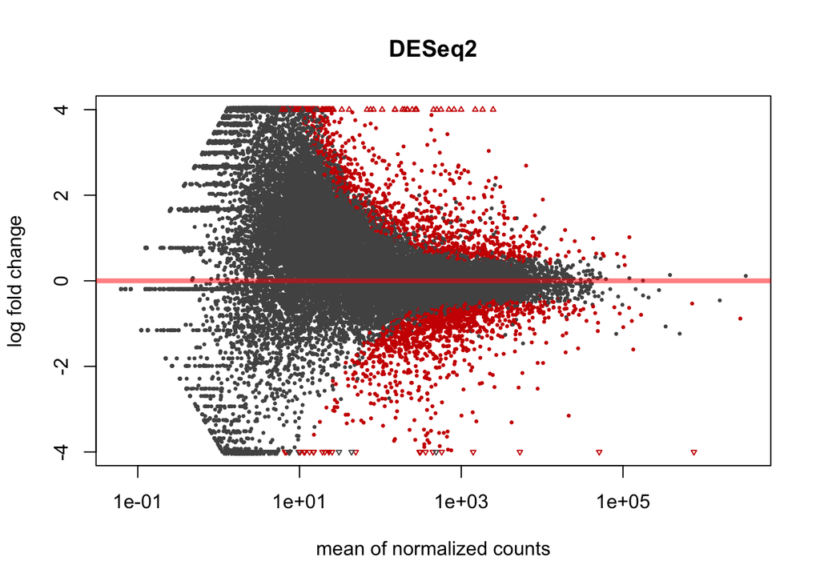

```r
plotMA(res1, main="DESeq2", ylim=c(-4,4))
```

6. 1. Use function plotCounts() to plot the counts for gene 497097. (b) Plot the unnormalized counts.

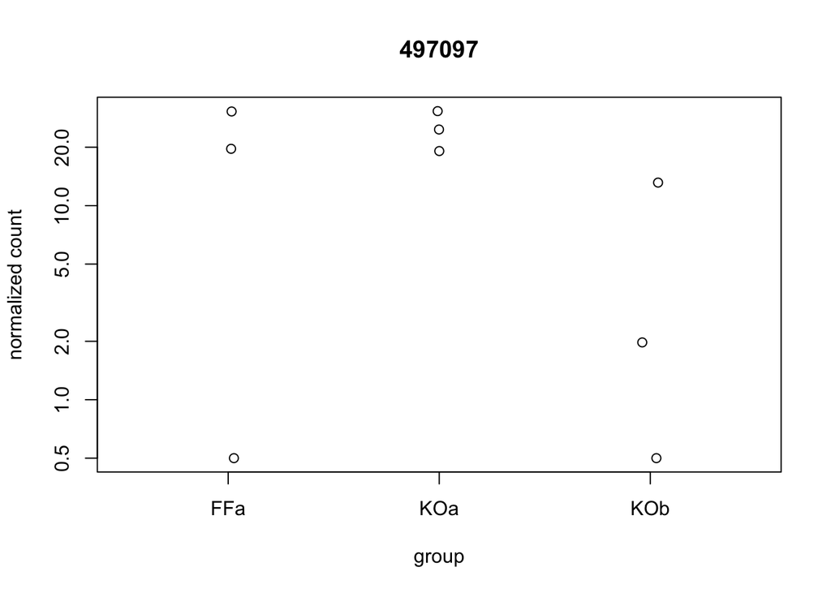

```r
plotCounts(ddsE,gene="497097",intgroup="condition")
```

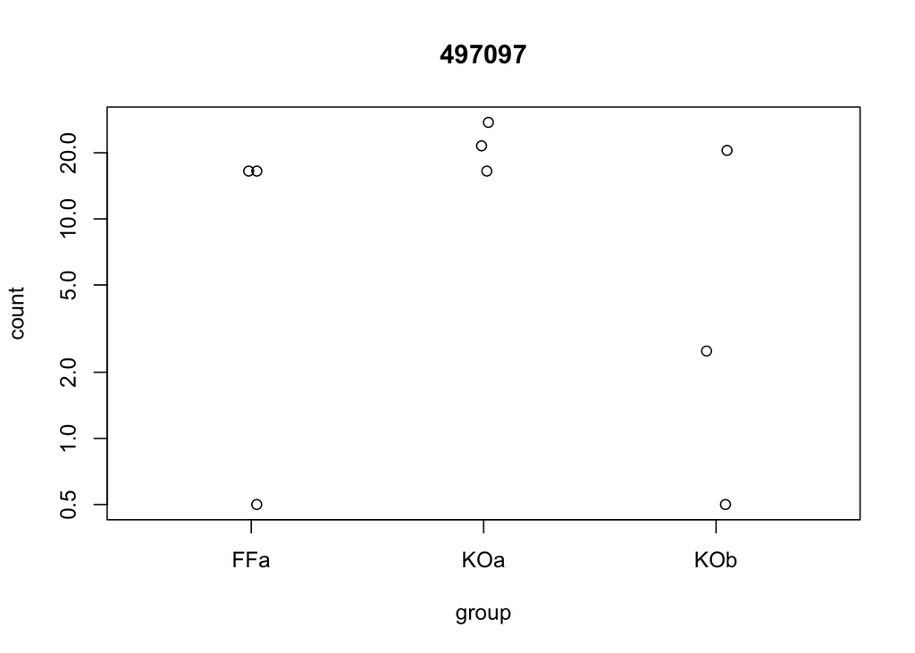

```r
plotCounts(ddsE,gene="497097",intgroup="condition",normalized = FALSE)
```